# Star Hotels Project

# Removing Columns

Columns no_of_previous_bookings_not_canceled and no_of_previous_cancellations due to their statistical irrelevance.

```python
logdata1.drop(columns=['no_of_previous_bookings_not_canceled', 'no_of_previous_cancellations'], inplace=True)
```

```python
logdata1.info()
```

```
<class 'pandas.core.frame.DataFrame'>
Int64Index: 42080 entries, 0 to 56924
Data columns (total 16 columns):
 #   Column                      Non-Null Count  Dtype
---  ------                      --------------  -----
 0   no_of_adults                42080 non-null  int64
 1   no_of_children              42080 non-null  int64
 2   no_of_weekend_nights        42080 non-null  int64
 3   no_of_week_nights           42080 non-null  int64
 4   type_of_meal_plan           42080 non-null  object
 5   required_car_parking_space  42080 non-null  int64
 6   room_type_reserved          42080 non-null  object
 7   lead_time                   42080 non-null  int64
 8   arrival_year                42080 non-null  int64
 9   arrival_month               42080 non-null  int64
 10  arrival_date                42080 non-null  int64
 11  market_segment_type         42080 non-null  object
 12  repeated_guest              42080 non-null  int64
 13  avg_price_per_room          42080 non-null  float64
 14  no_of_special_requests      42080 non-null  int64
 15  booking_status              42080 non-null  object
dtypes: float64(1), int64(11), object(4)
memory usage: 6.5+ MB
```

The columns were removed.

```
booking_status              Canceled  Not_Canceled    All
required_car_parking_space
All                            14487         27593  42080
0                              14307         26349  40656
1                                180          1244   1424
------------------------------------------------------------------------------------------------------------------------
```

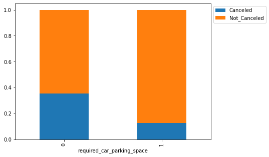

```python
stacked_barplot(logdata1, "required_car_parking_space", "booking_status")
```

Requiring a parking space is a customer profile that reduces cancellations.

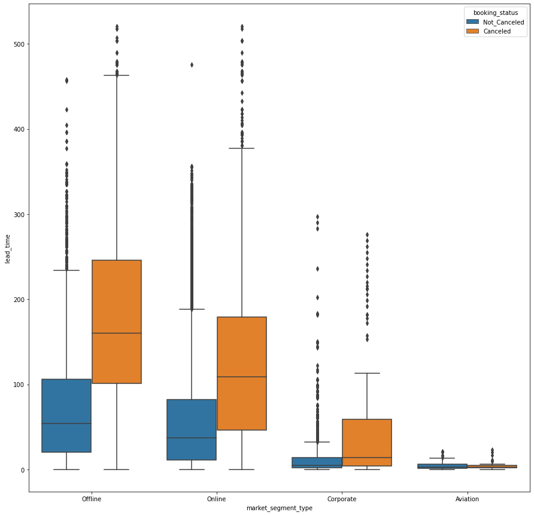

```python
fig, ax = plt.subplots(figsize = (15,15))
a = sns.boxplot(x= "market_segment_type", y = 'lead_time' , data = logdata1, hue = 'booking_status')
plt.show()
```

- Longer lead times appear to increase cancellation rates.

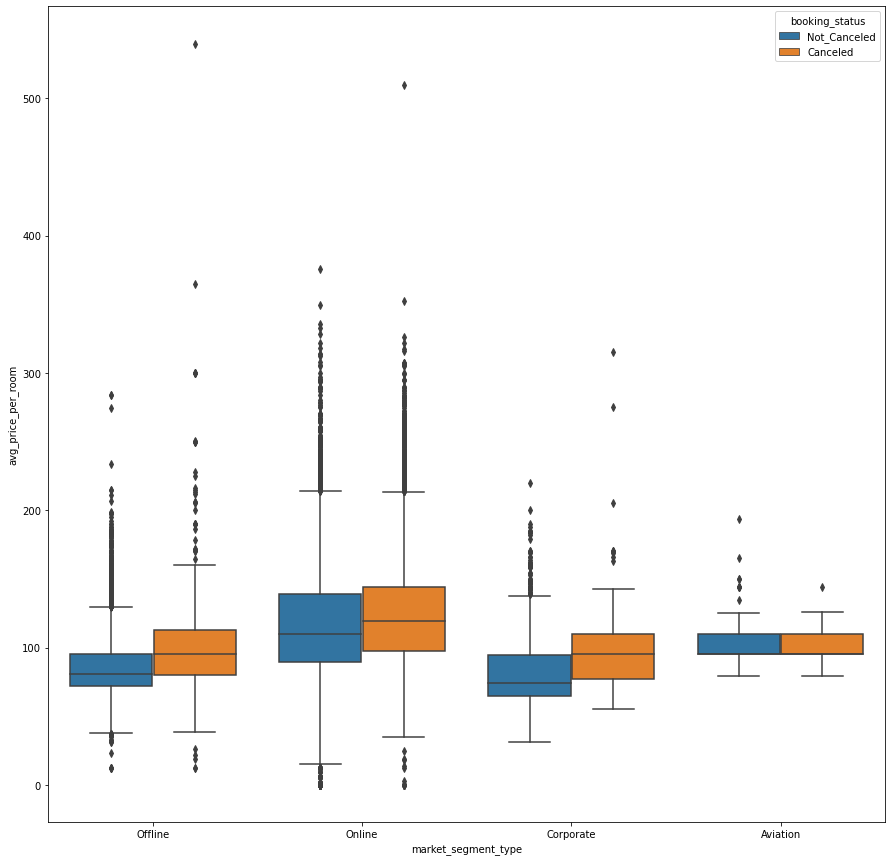

```python
fig, ax = plt.subplots(figsize = (15,15))
a = sns.boxplot(x= "market_segment_type", y = 'avg_price_per_room' , data = logdata1, hue = 'booking_status')
plt.show()
```

- Online bookings pay the most.
- Higher price per booking appears to lead to more cancellations.

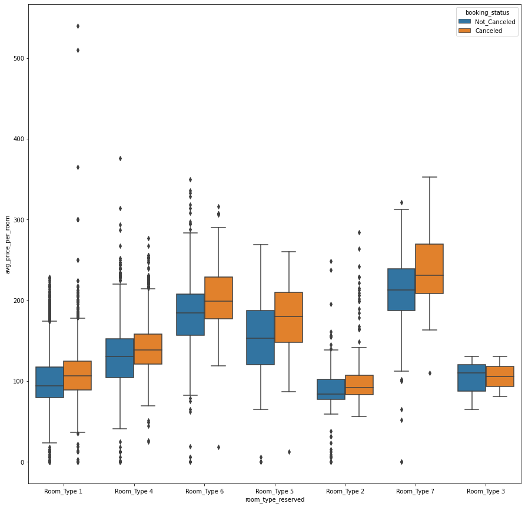

```python
fig, ax = plt.subplots(figsize = (15,15))
a = sns.boxplot(x= "room_type_reserved", y = 'avg_price_per_room' , data = logdata1, hue = 'booking_status')
plt.show()
```

- Room type 7 is the most expensive room followed by Room type 6.
- Cancellations appear to occur more for higher priced rooms.

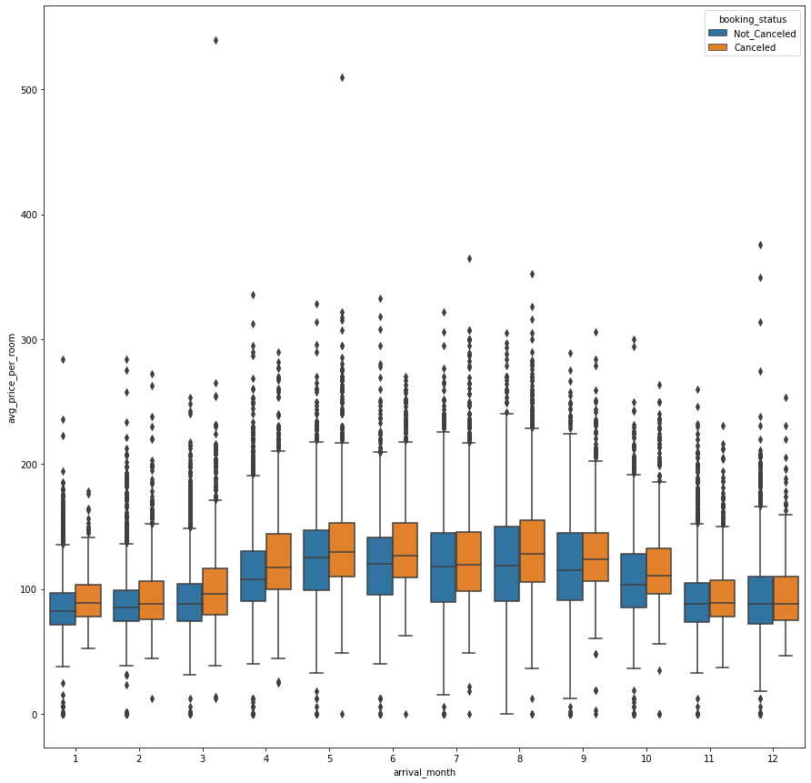

```python
fig, ax = plt.subplots(figsize = (15,15))
a = sns.boxplot(x= "arrival_month", y = 'avg_price_per_room' , data = logdata1, hue = 'booking_status')
plt.show()
```

- August appears to have the largest price differentiation for not cancels and cancels.

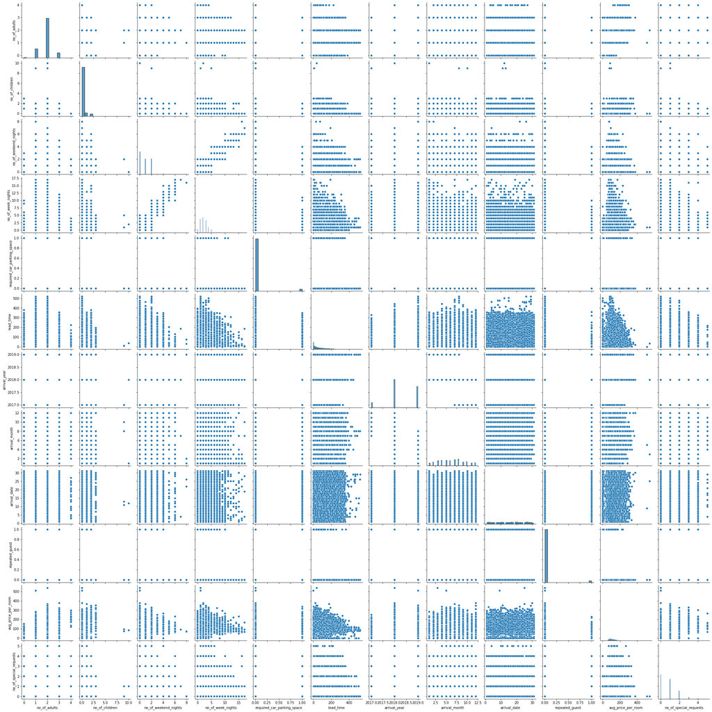

```python
sns.pairplot(logdata1)
```

```python
logdata1.corr()
```

|  | no_of_adults | no_of_children | no_of_weekend_nights | no_of_week_nights | required_car_parking_space | lead_time | arrival_year | arrival_month | arrival_date | repeated_guest | avg_price_per_room | no_of_special_requests |
| --- | --- | --- | --- | --- | --- | --- | --- | --- | --- | --- | --- | --- |
| no_of_adults | 1.000000 | -0.049075 | 0.083324 | 0.109529 | -0.014679 | 0.151196 | 0.087842 | 0.001327 | 0.006756 | -0.240757 | 0.345834 | 0.116522 |
| no_of_children | -0.049075 | 1.000000 | 0.015844 | 0.022252 | 0.015829 | 0.036246 | 0.013518 | 0.012222 | 0.015471 | -0.047714 | 0.362023 | 0.063236 |
| no_of_weekend_nights | 0.083324 | 0.015844 | 1.000000 | 0.231018 | -0.053362 | 0.110101 | 0.023234 | 0.000977 | -0.001494 | -0.081971 | -0.019727 | 0.009943 |
| no_of_week_nights | 0.109529 | 0.022252 | 0.231018 | 1.000000 | -0.060830 | 0.204544 | 0.046807 | 0.000576 | -0.015457 | -0.108824 | 0.001096 | 0.030310 |
| required_car_parking_space | -0.014679 | 0.015829 | -0.053362 | -0.060830 | 1.000000 | -0.044223 | -0.046845 | 0.010758 | 0.001491 | 0.129029 | 0.036324 | 0.062656 |
| lead_time | 0.151196 | 0.036246 | 0.110101 | 0.204544 | -0.044223 | 1.000000 | 0.209290 | 0.108008 | 0.035548 | -0.142668 | -0.020588 | 0.027974 |
| arrival_year | 0.087842 | 0.013518 | 0.023234 | 0.046807 | -0.046845 | 0.209290 | 1.000000 | -0.469634 | -0.003778 | -0.014799 | 0.238934 | 0.032659 |
| arrival_month | 0.001327 | 0.012222 | 0.000977 | 0.000576 | 0.010758 | 0.108008 | -0.469634 | 1.000000 | -0.004713 | -0.005397 | 0.074690 | 0.071519 |
| arrival_date | 0.006756 | 0.015471 | -0.001494 | -0.015457 | 0.001491 | 0.035548 | -0.003778 | -0.004713 | 1.000000 | -0.005869 | 0.012771 | -0.001166 |
| repeated_guest | -0.240757 | -0.047714 | -0.081971 | -0.108824 | 0.129029 | -0.142668 | -0.014799 | -0.005397 | -0.005869 | 1.000000 | -0.147355 | -0.022026 |
| avg_price_per_room | 0.345834 | 0.362023 | -0.019727 | 0.001096 | 0.036324 | -0.020588 | 0.238934 | 0.074690 | 0.012771 | -0.147355 | 1.000000 | 0.146896 |
| no_of_special_requests | 0.116522 | 0.063236 | 0.009943 | 0.030310 | 0.062656 | 0.027974 | 0.032659 | 0.071519 | -0.001166 | -0.022026 | 0.146896 | 1.000000 |

# Data Refinement Summary

- Complementary Bookings were removed.
- Previous bookings not canceled and previous cancellation columns were removed due to statistical irrelevance.

## Preparing the data for modeling

```python
scale_mapper = {2:0}
logdata1["booking_status"] = logdata1["booking_status"].replace(scale_mapper)

logdata1.head()
```

[output not shown]

```python
scale_mapper = {"Meal Plan 1":1, "Meal Plan 2":2, "Meal Plan 3":3, "Not Selected":4}
logdata1["type_of_meal_plan"] = logdata1["type_of_meal_plan"].replace(scale_mapper)

logdata1.head()
```

[output not shown]

```python
scale_mapper = {"Room_Type 1":1, "Room_Type 2":2, "Room_Type 3":3, "Room_Type 4":4, "Room_Type 5":5, "Room_Type 6":6, "Room_Type 7":7}
logdata1["room_type_reserved"] = logdata1["room_type_reserved"].replace(scale_mapper)

logdata1.head()
```

|  | no_of_adults | no_of_children | no_of_weekend_nights | no_of_week_nights | type_of_meal_plan | required_car_parking_space | room_type_reserved | lead_time | arrival_year | arrival_month | arrival_date | market_segment_type | repeated_guest | avg_price_per_room | no_of_special_requests | booking_status |
| --- | --- | --- | --- | --- | --- | --- | --- | --- | --- | --- | --- | --- | --- | --- | --- | --- |
| 0 | 2 | 0 | 1 | 2 | 1 | 0 | 1 | 224 | 2017 | 10 | 2 | 2 | 0 | 65.00 | 0 | 0 |
| 1 | 2 | 0 | 2 | 3 | 4 | 0 | 1 | 5 | 2018 | 11 | 6 | 1 | 0 | 106.68 | 1 | 0 |
| 2 | 1 | 0 | 2 | 1 | 1 | 0 | 1 | 1 | 2018 | 2 | 28 | 1 | 0 | 60.00 | 0 | 1 |
| 3 | 2 | 0 | 0 | 2 | 1 | 0 | 1 | 211 | 2018 | 5 | 20 | 1 | 0 | 100.00 | 0 | 1 |
| 4 | 3 | 0 | 0 | 3 | 4 | 0 | 1 | 277 | 2019 | 7 | 13 | 1 | 0 | 89.10 | 2 | 1 |

```python
scale_mapper = {"Online":1, "Offline":2, "Corporate":3, "Aviation":4}
logdata1["market_segment_type"] = logdata1["market_segment_type"].replace(scale_mapper)

logdata1.head()
```

|  | no_of_adults | no_of_children | no_of_weekend_nights | no_of_week_nights | type_of_meal_plan | required_car_parking_space | room_type_reserved | lead_time | arrival_year | arrival_month | arrival_date | market_segment_type | repeated_guest | avg_price_per_room | no_of_special_requests | booking_status |
| --- | --- | --- | --- | --- | --- | --- | --- | --- | --- | --- | --- | --- | --- | --- | --- | --- |
| 0 | 2 | 0 | 1 | 2 | 1 | 0 | 1 | 224 | 2017 | 10 | 2 | 2 | 0 | 65.00 | 0 | 0 |
| 1 | 2 | 0 | 2 | 3 | 4 | 0 | 1 | 5 | 2018 | 11 | 6 | 1 | 0 | 106.68 | 1 | 0 |
| 2 | 1 | 0 | 2 | 1 | 1 | 0 | 1 | 1 | 2018 | 2 | 28 | 1 | 0 | 60.00 | 0 | 1 |
| 3 | 2 | 0 | 0 | 2 | 1 | 0 | 1 | 211 | 2018 | 5 | 20 | 1 | 0 | 100.00 | 0 | 1 |
| 4 | 3 | 0 | 0 | 3 | 4 | 0 | 1 | 277 | 2019 | 7 | 13 | 1 | 0 | 89.10 | 2 | 1 |

## Additional EDA

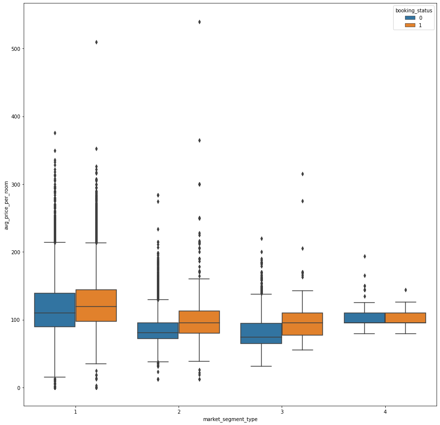

```python
fig, ax = plt.subplots(figsize = (15,15))
a = sns.boxplot(x= "market_segment_type", y = 'avg_price_per_room' , data = logdata1, hue = 'booking_status')
plt.show()
```

# Setting up the Training Data

```python
X = logdata1.drop(["booking_status"], axis=1)
Y = logdata1["booking_status"]

X = pd.get_dummies(X, drop_first=True)

# Splitting data in train and test sets
X_train, X_test, y_train, y_test = train_test_split(
    X, Y, test_size=0.30, random_state=1
)
```

```python
print("Shape of Training set : ", X_train.shape)
print("Shape of test set : ", X_test.shape)
print("Percentage of classes in training set:")
print(y_train.value_counts(normalize=True))
print("Percentage of classes in test set:")
print(y_test.value_counts(normalize=True))
```

```
Shape of Training set :  (29456, 15)
Shape of test set :  (12624, 15)
Percentage of classes in training set:
0    0.654264
1    0.345736
Name: booking_status, dtype: float64
Percentage of classes in test set:
0    0.659141
1    0.340859
Name: booking_status, dtype: float64
```

# Building the Model

## Model evaluation criterion

## Model can make wrong predictions as:¶

- Predicting a person will cancel but in reality they do not cancel.
- Predicting a person will not cancel but in reality they do cancel.

## Which case is more important?

- Both the cases are important as:
- If we predict a person will cancel but actually will not cancel then that person will not be able to book a room constituting an opportunity loss.
- If we predict a person will not cancel but actually will cancel then the hotel might not be able to fill the vacancy resulting in a loss due to vacancy.

```python
# defining a function to compute different metrics to check performance of a classification model built using statsmodels
def model_performance_classification_statsmodels(
    model, predictors, target, threshold=0.5
):
    """
    Function to compute different metrics to check classification model performance

    model: classifier
    predictors: independent variables
    target: dependent variable
    threshold: threshold for classifying the observation as class 1
    """

    # checking which probabilities are greater than threshold
    pred_temp = model.predict(predictors) > threshold
    # rounding off the above values to get classes
    pred = np.round(pred_temp)

    acc = accuracy_score(target, pred)  # to compute Accuracy
    recall = recall_score(target, pred)  # to compute Recall
    precision = precision_score(target, pred)  # to compute Precision
    f1 = f1_score(target, pred)  # to compute F1-score

    # creating a dataframe of metrics
    df_perf = pd.DataFrame(
        {"Accuracy": acc, "Recall": recall, "Precision": precision, "F1": f1,},
        index=[0],
    )

    return df_perf
```

```python
# defining a function to plot the confusion_matrix of a classification model


def confusion_matrix_statsmodels(model, predictors, target, threshold=0.5):
    """
    To plot the confusion_matrix with percentages

    model: classifier
    predictors: independent variables
    target: dependent variable
    threshold: threshold for classifying the observation as class 1
    """
    y_pred = model.predict(predictors) > threshold
    cm = confusion_matrix(target, y_pred)
    labels = np.asarray(
        [
            ["{0:0.0f}".format(item) + "\n{0:.2%}".format(item / cm.flatten().sum())]
            for item in cm.flatten()
        ]
    ).reshape(2, 2)

    plt.figure(figsize=(6, 4))
    sns.heatmap(cm, annot=labels, fmt="")
    plt.ylabel("True label")
    plt.xlabel("Predicted label")
```

## Logistic Regression (with Sklearn library)

```python
# There are different solvers available in Sklearn logistic regression
# The newton-cg solver is faster for high-dimensional data

lg = LogisticRegression(solver="newton-cg", random_state=1)
model = lg.fit(X_train, y_train)
```

Checking model performance on training set

```python
# predicting on training set
y_pred_train = lg.predict(X_train)
```

```python
print("Training set performance:")
print("Accuracy:", accuracy_score(y_train, y_pred_train))
print("Precision:", precision_score(y_train, y_pred_train))
print("Recall:", recall_score(y_train, y_pred_train))
print("F1:", f1_score(y_train, y_pred_train))
```

```
Training set performance:
Accuracy: 0.7869364475828354
Precision: 0.7333970377448639
Recall: 0.6029065200314219
F1: 0.6617805561543437
```

Checking performance on test set

```python
# predicting on the test set
y_pred_test = lg.predict(X_test)
```

```python
print("Test set performance:")
print("Accuracy:", accuracy_score(y_test, y_pred_test))
print("Precision:", precision_score(y_test, y_pred_test))
print("Recall:", recall_score(y_test, y_pred_test))
print("F1:", f1_score(y_test, y_pred_test))
```

```
Test set performance:
Accuracy: 0.7896070975918885
Precision: 0.7238379994563741
Recall: 0.6188705554264466
F1: 0.6672513154597846
```

## Observations

- The training and testing f1_scores are 0.66 and 0.67, respectably.
- f1_score on the train and test sets are comparable.
- This shows that the model is showing generalised results.
- We have build a logistic regression model which shows good performance on the train and test sets but to identify significant variables we will have to build a logistic regression model using the statsmodels library.
- We will now perform logistic regression using statsmodels, a Python module that provides functions for the estimation of many statistical models, as well as for conducting statistical tests, and statistical data exploration.
- Using statsmodels, we will be able to check the statistical validity of our model - identify the significant predictors from p-values that we get for each predictor variable.

## Logistic Regression (with statsmodels library)

```python
# adding constant
X = sm.add_constant(X)
```

```python
# fitting logistic regression model
logit = sm.Logit(y_train, X_train.astype(float))
lg = logit.fit(disp=False)

print(lg.summary())
```

```
                           Logit Regression Results
==============================================================================
Dep. Variable:         booking_status   No. Observations:                29456
Model:                          Logit   Df Residuals:                    29441
Method:                           MLE   Df Model:                           14
Date:                Thu, 21 Oct 2021   Pseudo R-squ.:                  0.3053
Time:                        01:11:41   Log-Likelihood:                -13194.
converged:                       True   LL-Null:                       -18992.
Covariance Type:            nonrobust   LLR p-value:                     0.000
==============================================================================================
                                 coef    std err          z      P>|z|      [0.025      0.975]
----------------------------------------------------------------------------------------------
no_of_adults                  -0.0995      0.034     -2.911      0.004      -0.167      -0.033
no_of_children                 0.0023      0.037      0.063      0.950      -0.070       0.075
no_of_weekend_nights           0.0276      0.018      1.568      0.117      -0.007       0.062
no_of_week_nights              0.0840      0.010      8.033      0.000       0.063       0.104
type_of_meal_plan              0.0956      0.013      7.181      0.000       0.070       0.122
required_car_parking_space    -1.4222      0.113    -12.556      0.000      -1.644      -1.200
room_type_reserved            -0.0499      0.013     -3.899      0.000      -0.075      -0.025
lead_time                      0.0155      0.000     63.799      0.000       0.015       0.016
arrival_year                  -0.0006   5.75e-05     -9.988      0.000      -0.001      -0.000
arrival_month                 -0.0384      0.006     -6.958      0.000      -0.049      -0.028
arrival_date                  -0.0011      0.002     -0.633      0.527      -0.004       0.002
market_segment_type           -1.4337      0.049    -29.221      0.000      -1.530      -1.338
repeated_guest                -1.3390      0.416     -3.215      0.001      -2.155      -0.523
avg_price_per_room             0.0168      0.001     30.066      0.000       0.016       0.018
no_of_special_requests        -1.2440      0.023    -54.293      0.000      -1.289      -1.199
==============================================================================================
```

```python
print("Training performance:")
model_performance_classification_statsmodels(lg, X_train, y_train)
```

```
Training performance:
```

|  | Accuracy | Recall | Precision | F1 |
| --- | --- | --- | --- | --- |
| 0 | 0.786902 | 0.603201 | 0.733142 | 0.661854 |

## Observations

- Negative values of the coefficient shows that probability of customer canceling decreases with the increase of corresponding attribute value.
- Positive values of the coefficient show that that probability of customer canceling increases with the increase of corresponding attribute value.
- p-value of a variable indicates if the variable is significant or not. If we consider the significance level to be 0.05 (5%), then any variable with a p-value less than 0.05 would be considered significant.
- But these variables might contain multicollinearity, which will affect the p-values.
- We will remove multicollinearity from the data to get reliable coefficients and p-values.

## Multicollinearity

```python
vif_series = pd.Series(
    [variance_inflation_factor(X_train.values, i) for i in range(X_train.shape[1])],
    index=X_train.columns,
    dtype=float,
)
print("Series before feature selection: \n\n{}\n".format(vif_series))
```

```
Series before feature selection:

no_of_adults                  19.696898
no_of_children                 1.400626
no_of_weekend_nights           2.177541
no_of_week_nights              3.765506
type_of_meal_plan              3.446148
required_car_parking_space     1.066129
room_type_reserved             4.564950
lead_time                      2.252888
arrival_year                  53.552582
arrival_month                  5.534002
arrival_date                   4.165793
market_segment_type            9.468424
repeated_guest                 1.363174
avg_price_per_room            17.194725
no_of_special_requests         2.003771
dtype: float64
```

```python
X_train1 = X_train.drop(["no_of_children", "no_of_weekend_nights", "arrival_date"], axis=1)

logit1 = sm.Logit(y_train, X_train1.astype(float))
lg1 = logit1.fit()

print(lg1.summary())
```

```
Optimization terminated successfully.
         Current function value: 0.447975
         Iterations 9
                           Logit Regression Results
==============================================================================
Dep. Variable:         booking_status   No. Observations:                29456
Model:                          Logit   Df Residuals:                    29444
Method:                           MLE   Df Model:                           11
Date:                Thu, 21 Oct 2021   Pseudo R-squ.:                  0.3052
Time:                        01:21:15   Log-Likelihood:                -13196.
converged:                       True   LL-Null:                       -18992.
Covariance Type:            nonrobust   LLR p-value:                     0.000
==============================================================================================
                                 coef    std err          z      P>|z|      [0.025      0.975]
----------------------------------------------------------------------------------------------
no_of_adults                  -0.0986      0.033     -2.992      0.003      -0.163      -0.034
no_of_week_nights              0.0876      0.010      8.574      0.000       0.068       0.108
type_of_meal_plan              0.0948      0.013      7.125      0.000       0.069       0.121
required_car_parking_space    -1.4261      0.113    -12.594      0.000      -1.648      -1.204
room_type_reserved            -0.0492      0.012     -3.948      0.000      -0.074      -0.025
lead_time                      0.0155      0.000     64.070      0.000       0.015       0.016
arrival_year                  -0.0006   5.56e-05    -10.294      0.000      -0.001      -0.000
arrival_month                 -0.0383      0.006     -6.943      0.000      -0.049      -0.027
market_segment_type           -1.4349      0.049    -29.252      0.000      -1.531      -1.339
repeated_guest                -1.3458      0.417     -3.231      0.001      -2.162      -0.529
avg_price_per_room             0.0167      0.001     30.958      0.000       0.016       0.018
no_of_special_requests        -1.2441      0.023    -54.305      0.000      -1.289      -1.199
==============================================================================================
```

No features have high P-Values greater than .05, so X_train1 as the final and lg1 as the final model.

## Coefficient interpretations

- Coefficient of number of weeknights, types of meal plans, lead time, and average price per room are positive. Due to the inversion the assigned values for cancellations, increases to these coefficients will increase the risk of cancellation.
- Coefficients of number of adults, required car parking space, arrival year, arrival month, market segment type, repeat guest, and number of special requests are negative so increase in these will lead to decrease in chances of a person canceling their booking.

## Converting coefficients to odds

- The coefficients of the logistic regression model are in terms of log(odd), to find the odds we have to take the exponential of the coefficients.
- Therefore, odds = exp(b)
- The percentage change in odds is given as odds = (exp(b) - 1) * 100

```python
# converting coefficients to odds
odds = np.exp(lg1.params)

# finding the percentage change
perc_change_odds = (np.exp(lg1.params) - 1) * 100

# removing limit from number of columns to display
pd.set_option("display.max_columns", None)

# adding the odds to a dataframe
pd.DataFrame({"Odds": odds, "Change_odd%": perc_change_odds}, index=X_train1.columns).T
```

|  | no_of_adults | no_of_week_nights | type_of_meal_plan | required_car_parking_space | room_type_reserved | lead_time | arrival_year | arrival_month | market_segment_type | repeated_guest | avg_price_per_room | no_of_special_requests |
| --- | --- | --- | --- | --- | --- | --- | --- | --- | --- | --- | --- | --- |
| Odds | 0.906099 | 1.091521 | 1.099452 | 0.240235 | 0.951994 | 1.015645 | 0.999428 | 0.962448 | 0.238147 | 0.260328 | 1.016885 | 0.288207 |
| Change_odd% | -9.390105 | 9.152085 | 9.945200 | -75.976467 | -4.800602 | 1.564514 | -0.057245 | -3.755195 | -76.185252 | -73.967192 | 1.688485 | -71.179294 |

## Checking model performance on the training set

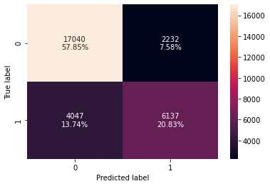

```python
# creating confusion matrix
confusion_matrix_statsmodels(lg1, X_train1, y_train)
```

```python
log_reg_model_train_perf = model_performance_classification_statsmodels(
    lg1, X_train1, y_train
)

print("Training performance:")
log_reg_model_train_perf
```

```
Training performance:
```

|  | Accuracy | Recall | Precision | F1 |
| --- | --- | --- | --- | --- |
| 0 | 0.786835 | 0.602612 | 0.733301 | 0.661564 |

## ROC-AUC

### ROC-AUC on training set

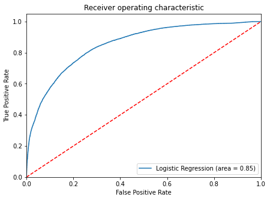

```python
logit_roc_auc_train = roc_auc_score(y_train, lg1.predict(X_train1))
fpr, tpr, thresholds = roc_curve(y_train, lg1.predict(X_train1))
plt.figure(figsize=(7, 5))
plt.plot(fpr, tpr, label="Logistic Regression (area = %0.2f)" % logit_roc_auc_train)
plt.plot([0, 1], [0, 1], "r--")
plt.xlim([0.0, 1.0])
plt.ylim([0.0, 1.05])
plt.xlabel("False Positive Rate")
plt.ylabel("True Positive Rate")
plt.title("Receiver operating characteristic")
plt.legend(loc="lower right")
plt.show()
```

Logistic Regression model is giving a good performance on training set.

# Logistic Model Summary

# Building a Decision Tree Model

## Import Additional Libraries

```python
from sklearn import metrics
from sklearn.model_selection import train_test_split
from sklearn.tree import DecisionTreeClassifier
from sklearn import tree
```

```python
logdata.info()
```

```
<class 'pandas.core.frame.DataFrame'>
RangeIndex: 56926 entries, 0 to 56925
Data columns (total 18 columns):
 #   Column                                Non-Null Count  Dtype
---  ------                                --------------  -----
 0   no_of_adults                          56926 non-null  int64
 1   no_of_children                        56926 non-null  int64
 2   no_of_weekend_nights                  56926 non-null  int64
 3   no_of_week_nights                     56926 non-null  int64
 4   type_of_meal_plan                     56926 non-null  object
 5   required_car_parking_space            56926 non-null  int64
 6   room_type_reserved                    56926 non-null  object
 7   lead_time                             56926 non-null  int64
 8   arrival_year                          56926 non-null  int64
 9   arrival_month                         56926 non-null  int64
 10  arrival_date                          56926 non-null  int64
 11  market_segment_type                   56926 non-null  object
 12  repeated_guest                        56926 non-null  int64
 13  no_of_previous_cancellations          56926 non-null  int64
 14  no_of_previous_bookings_not_canceled  56926 non-null  int64
 15  avg_price_per_room                    56926 non-null  float64
 16  no_of_special_requests                56926 non-null  int64
 17  booking_status                        56926 non-null  object
dtypes: float64(1), int64(13), object(4)
memory usage: 7.8+ MB
```

## Prepare Data for Decision Tree

```python
treedata = logdata.drop_duplicates() #Remove duplicates
```

```python
treedata.info()
```

```
<class 'pandas.core.frame.DataFrame'>
Int64Index: 42576 entries, 0 to 56924
Data columns (total 18 columns):
 #   Column                                Non-Null Count  Dtype
---  ------                                --------------  -----
 0   no_of_adults                          42576 non-null  int64
 1   no_of_children                        42576 non-null  int64
 2   no_of_weekend_nights                  42576 non-null  int64
 3   no_of_week_nights                     42576 non-null  int64
 4   type_of_meal_plan                     42576 non-null  object
 5   required_car_parking_space            42576 non-null  int64
 6   room_type_reserved                    42576 non-null  object
 7   lead_time                             42576 non-null  int64
 8   arrival_year                          42576 non-null  int64
 9   arrival_month                         42576 non-null  int64
 10  arrival_date                          42576 non-null  int64
 11  market_segment_type                   42576 non-null  object
 12  repeated_guest                        42576 non-null  int64
 13  no_of_previous_cancellations          42576 non-null  int64
 14  no_of_previous_bookings_not_canceled  42576 non-null  int64
 15  avg_price_per_room                    42576 non-null  float64
 16  no_of_special_requests                42576 non-null  int64
 17  booking_status                        42576 non-null  object
dtypes: float64(1), int64(13), object(4)
memory usage: 6.2+ MB
```

```python
treedata.drop(treedata.loc[treedata['market_segment_type']=='Complementary'].index, inplace=True) #Remove Complementary Bookings
```

```python
treedata.info()
```

```
<class 'pandas.core.frame.DataFrame'>
Int64Index: 42080 entries, 0 to 56924
Data columns (total 18 columns):
 #   Column                                Non-Null Count  Dtype
---  ------                                --------------  -----
 0   no_of_adults                          42080 non-null  int64
 1   no_of_children                        42080 non-null  int64
 2   no_of_weekend_nights                  42080 non-null  int64
 3   no_of_week_nights                     42080 non-null  int64
 4   type_of_meal_plan                     42080 non-null  object
 5   required_car_parking_space            42080 non-null  int64
 6   room_type_reserved                    42080 non-null  object
 7   lead_time                             42080 non-null  int64
 8   arrival_year                          42080 non-null  int64
 9   arrival_month                         42080 non-null  int64
 10  arrival_date                          42080 non-null  int64
 11  market_segment_type                   42080 non-null  object
 12  repeated_guest                        42080 non-null  int64
 13  no_of_previous_cancellations          42080 non-null  int64
 14  no_of_previous_bookings_not_canceled  42080 non-null  int64
 15  avg_price_per_room                    42080 non-null  float64
 16  no_of_special_requests                42080 non-null  int64
 17  booking_status                        42080 non-null  object
dtypes: float64(1), int64(13), object(4)
memory usage: 6.1+ MB
```

```python
for feature in treedata.columns: # Loop through all columns in the dataframe
    if treedata[feature].dtype == 'object': # Only apply for columns with categorical strings
        treedata[feature] = pd.Categorical(treedata[feature])# Replace strings with an integer
treedata.head(10)
```

|  | no_of_adults | no_of_children | no_of_weekend_nights | no_of_week_nights | type_of_meal_plan | required_car_parking_space | room_type_reserved | lead_time | arrival_year | arrival_month | arrival_date | market_segment_type | repeated_guest | no_of_previous_cancellations | no_of_previous_bookings_not_canceled | avg_price_per_room | no_of_special_requests | booking_status |
| --- | --- | --- | --- | --- | --- | --- | --- | --- | --- | --- | --- | --- | --- | --- | --- | --- | --- | --- |
| 0 | 2 | 0 | 1 | 2 | Meal Plan 1 | 0 | Room_Type 1 | 224 | 2017 | 10 | 2 | Offline | 0 | 0 | 0 | 65.00 | 0 | Not_Canceled |
| 1 | 2 | 0 | 2 | 3 | Not Selected | 0 | Room_Type 1 | 5 | 2018 | 11 | 6 | Online | 0 | 0 | 0 | 106.68 | 1 | Not_Canceled |
| 2 | 1 | 0 | 2 | 1 | Meal Plan 1 | 0 | Room_Type 1 | 1 | 2018 | 2 | 28 | Online | 0 | 0 | 0 | 60.00 | 0 | Canceled |
| 3 | 2 | 0 | 0 | 2 | Meal Plan 1 | 0 | Room_Type 1 | 211 | 2018 | 5 | 20 | Online | 0 | 0 | 0 | 100.00 | 0 | Canceled |
| 4 | 3 | 0 | 0 | 3 | Not Selected | 0 | Room_Type 1 | 277 | 2019 | 7 | 13 | Online | 0 | 0 | 0 | 89.10 | 2 | Canceled |
| 5 | 2 | 0 | 1 | 1 | Not Selected | 0 | Room_Type 1 | 48 | 2018 | 4 | 11 | Online | 0 | 0 | 0 | 94.50 | 0 | Canceled |
| 6 | 1 | 0 | 0 | 3 | Meal Plan 1 | 0 | Room_Type 1 | 38 | 2019 | 6 | 20 | Online | 0 | 0 | 0 | 160.00 | 1 | Not_Canceled |
| 7 | 2 | 0 | 0 | 2 | Meal Plan 2 | 0 | Room_Type 1 | 346 | 2018 | 9 | 13 | Online | 0 | 0 | 0 | 115.00 | 1 | Canceled |
| 8 | 2 | 0 | 1 | 3 | Meal Plan 1 | 0 | Room_Type 1 | 34 | 2017 | 10 | 15 | Online | 0 | 0 | 0 | 107.55 | 1 | Not_Canceled |
| 9 | 2 | 0 | 0 | 4 | Meal Plan 1 | 0 | Room_Type 1 | 133 | 2019 | 4 | 19 | Offline | 0 | 0 | 0 | 124.00 | 0 | Not_Canceled |

```python
treedata.info()
```

```
<class 'pandas.core.frame.DataFrame'>
Int64Index: 42080 entries, 0 to 56924
Data columns (total 18 columns):
 #   Column                                Non-Null Count  Dtype
---  ------                                --------------  -----
 0   no_of_adults                          42080 non-null  int64
 1   no_of_children                        42080 non-null  int64
 2   no_of_weekend_nights                  42080 non-null  int64
 3   no_of_week_nights                     42080 non-null  int64
 4   type_of_meal_plan                     42080 non-null  category
 5   required_car_parking_space            42080 non-null  int64
 6   room_type_reserved                    42080 non-null  category
 7   lead_time                             42080 non-null  int64
 8   arrival_year                          42080 non-null  int64
 9   arrival_month                         42080 non-null  int64
 10  arrival_date                          42080 non-null  int64
 11  market_segment_type                   42080 non-null  category
 12  repeated_guest                        42080 non-null  int64
 13  no_of_previous_cancellations          42080 non-null  int64
 14  no_of_previous_bookings_not_canceled  42080 non-null  int64
 15  avg_price_per_room                    42080 non-null  float64
 16  no_of_special_requests                42080 non-null  int64
 17  booking_status                        42080 non-null  category
dtypes: category(4), float64(1), int64(13)
memory usage: 5.0 MB
```

```python
# EDA on Categorical Data
print(treedata.type_of_meal_plan.value_counts())
print(treedata.room_type_reserved.value_counts())
print(treedata.market_segment_type.value_counts())
print(treedata.booking_status.value_counts())
```

```
Meal Plan 1     31392
Not Selected     8710
Meal Plan 2      1977
Meal Plan 3         1
Name: type_of_meal_plan, dtype: int64
Room_Type 1    29417
Room_Type 4     9307
Room_Type 6     1518
Room_Type 5      879
Room_Type 2      697
Room_Type 7      257
Room_Type 3        5
Name: room_type_reserved, dtype: int64
Online       34169
Offline       5777
Corporate     1939
Aviation       195
Name: market_segment_type, dtype: int64
Not_Canceled    27593
Canceled        14487
Name: booking_status, dtype: int64
```

```python
replaceStruct = {
                "booking_status":     {"Not_Canceled": 1, "Canceled": 2}
                    }
```

Not Canceled is now 1. Canceled is now 2.

```python
treedata=treedata.replace(replaceStruct)
treedata.head(10)
```

|  | no_of_adults | no_of_children | no_of_weekend_nights | no_of_week_nights | type_of_meal_plan | required_car_parking_space | room_type_reserved | lead_time | arrival_year | arrival_month | arrival_date | market_segment_type | repeated_guest | no_of_previous_cancellations | no_of_previous_bookings_not_canceled | avg_price_per_room | no_of_special_requests | booking_status |
| --- | --- | --- | --- | --- | --- | --- | --- | --- | --- | --- | --- | --- | --- | --- | --- | --- | --- | --- |
| 0 | 2 | 0 | 1 | 2 | Meal Plan 1 | 0 | Room_Type 1 | 224 | 2017 | 10 | 2 | Offline | 0 | 0 | 0 | 65.00 | 0 | 1 |
| 1 | 2 | 0 | 2 | 3 | Not Selected | 0 | Room_Type 1 | 5 | 2018 | 11 | 6 | Online | 0 | 0 | 0 | 106.68 | 1 | 1 |
| 2 | 1 | 0 | 2 | 1 | Meal Plan 1 | 0 | Room_Type 1 | 1 | 2018 | 2 | 28 | Online | 0 | 0 | 0 | 60.00 | 0 | 2 |
| 3 | 2 | 0 | 0 | 2 | Meal Plan 1 | 0 | Room_Type 1 | 211 | 2018 | 5 | 20 | Online | 0 | 0 | 0 | 100.00 | 0 | 2 |
| 4 | 3 | 0 | 0 | 3 | Not Selected | 0 | Room_Type 1 | 277 | 2019 | 7 | 13 | Online | 0 | 0 | 0 | 89.10 | 2 | 2 |
| 5 | 2 | 0 | 1 | 1 | Not Selected | 0 | Room_Type 1 | 48 | 2018 | 4 | 11 | Online | 0 | 0 | 0 | 94.50 | 0 | 2 |
| 6 | 1 | 0 | 0 | 3 | Meal Plan 1 | 0 | Room_Type 1 | 38 | 2019 | 6 | 20 | Online | 0 | 0 | 0 | 160.00 | 1 | 1 |
| 7 | 2 | 0 | 0 | 2 | Meal Plan 2 | 0 | Room_Type 1 | 346 | 2018 | 9 | 13 | Online | 0 | 0 | 0 | 115.00 | 1 | 2 |
| 8 | 2 | 0 | 1 | 3 | Meal Plan 1 | 0 | Room_Type 1 | 34 | 2017 | 10 | 15 | Online | 0 | 0 | 0 | 107.55 | 1 | 1 |
| 9 | 2 | 0 | 0 | 4 | Meal Plan 1 | 0 | Room_Type 1 | 133 | 2019 | 4 | 19 | Offline | 0 | 0 | 0 | 124.00 | 0 | 1 |

```python
treedata.info()
```

```
<class 'pandas.core.frame.DataFrame'>
Int64Index: 42080 entries, 0 to 56924
Data columns (total 18 columns):
 #   Column                                Non-Null Count  Dtype
---  ------                                --------------  -----
 0   no_of_adults                          42080 non-null  int64
 1   no_of_children                        42080 non-null  int64
 2   no_of_weekend_nights                  42080 non-null  int64
 3   no_of_week_nights                     42080 non-null  int64
 4   type_of_meal_plan                     42080 non-null  category
 5   required_car_parking_space            42080 non-null  int64
 6   room_type_reserved                    42080 non-null  category
 7   lead_time                             42080 non-null  int64
 8   arrival_year                          42080 non-null  int64
 9   arrival_month                         42080 non-null  int64
 10  arrival_date                          42080 non-null  int64
 11  market_segment_type                   42080 non-null  category
 12  repeated_guest                        42080 non-null  int64
 13  no_of_previous_cancellations          42080 non-null  int64
 14  no_of_previous_bookings_not_canceled  42080 non-null  int64
 15  avg_price_per_room                    42080 non-null  float64
 16  no_of_special_requests                42080 non-null  int64
 17  booking_status                        42080 non-null  int64
dtypes: category(3), float64(1), int64(14)
memory usage: 5.3 MB
```

```python
X = treedata.drop("booking_status" , axis=1)
y = treedata.pop("booking_status")
```

```python
# encoding the categorical variables
X = pd.get_dummies(X, drop_first=True)
X.head()
```

|  | no_of_adults | no_of_children | no_of_weekend_nights | no_of_week_nights | required_car_parking_space | lead_time | arrival_year | arrival_month | arrival_date | repeated_guest | no_of_previous_cancellations | no_of_previous_bookings_not_canceled | avg_price_per_room | no_of_special_requests | type_of_meal_plan_Meal Plan 2 | type_of_meal_plan_Meal Plan 3 | type_of_meal_plan_Not Selected | room_type_reserved_Room_Type 2 | room_type_reserved_Room_Type 3 | room_type_reserved_Room_Type 4 | room_type_reserved_Room_Type 5 | room_type_reserved_Room_Type 6 | room_type_reserved_Room_Type 7 | market_segment_type_Corporate | market_segment_type_Offline | market_segment_type_Online |
| --- | --- | --- | --- | --- | --- | --- | --- | --- | --- | --- | --- | --- | --- | --- | --- | --- | --- | --- | --- | --- | --- | --- | --- | --- | --- | --- |
| 0 | 2 | 0 | 1 | 2 | 0 | 224 | 2017 | 10 | 2 | 0 | 0 | 0 | 65.00 | 0 | 0 | 0 | 0 | 0 | 0 | 0 | 0 | 0 | 0 | 0 | 1 | 0 |
| 1 | 2 | 0 | 2 | 3 | 0 | 5 | 2018 | 11 | 6 | 0 | 0 | 0 | 106.68 | 1 | 0 | 0 | 1 | 0 | 0 | 0 | 0 | 0 | 0 | 0 | 0 | 1 |
| 2 | 1 | 0 | 2 | 1 | 0 | 1 | 2018 | 2 | 28 | 0 | 0 | 0 | 60.00 | 0 | 0 | 0 | 0 | 0 | 0 | 0 | 0 | 0 | 0 | 0 | 0 | 1 |
| 3 | 2 | 0 | 0 | 2 | 0 | 211 | 2018 | 5 | 20 | 0 | 0 | 0 | 100.00 | 0 | 0 | 0 | 0 | 0 | 0 | 0 | 0 | 0 | 0 | 0 | 0 | 1 |
| 4 | 3 | 0 | 0 | 3 | 0 | 277 | 2019 | 7 | 13 | 0 | 0 | 0 | 89.10 | 2 | 0 | 0 | 1 | 0 | 0 | 0 | 0 | 0 | 0 | 0 | 0 | 1 |

```python
# Split the data
X_train2, X_test2, y_train2, y_test2 = train_test_split(X, y, test_size=0.3, random_state=1)
```

```python
print("Number of rows in train data =", X_train2.shape[0])
print("Number of rows in test data =", X_test2.shape[0])
```

```
Number of rows in train data = 29456
Number of rows in test data = 12624
```

```python
print("Percentage of classes in training set:")
print(y_train2.value_counts(normalize=True))
print("Percentage of classes in test set:")
print(y_test2.value_counts(normalize=True))
```

```
Percentage of classes in training set:
1    0.654264
2    0.345736
Name: booking_status, dtype: float64
Percentage of classes in test set:
1    0.659141
2    0.340859
Name: booking_status, dtype: float64
```

# Build Decision Tree Model

### Model evaluation criterion

### Model can make wrong predictions as:

- Predicting a customer will not cancel but in reality the customer cancels.
- Predicting a customer will cancel but in reality the customer would not cancel.

### Which case is more important?

Both are important. If we predict a booking will cancel, but the customer would not cancel in reality an opportunity loss occurs due to ignoring a customer profile. If we predict a booking will not cancel, but the customer does cancel, the hotel may not be able to find another booking to replace the expected revenue.

```python
# defining a function to compute different metrics to check performance of a classification model built using sklearn
def model_performance_classification_sklearn(model, predictors, target):
    """
    Function to compute different metrics to check classification model performance

    model: classifier
    predictors: independent variables
    target: dependent variable
    """

    # predicting using the independent variables
    pred = model.predict(predictors)

    acc = accuracy_score(target, pred)  # to compute Accuracy
    recall = recall_score(target, pred)  # to compute Recall
    precision = precision_score(target, pred)  # to compute Precision
    f1 = f1_score(target, pred)  # to compute F1-score

    # creating a dataframe of metrics
    df_perf = pd.DataFrame(
        {"Accuracy": acc, "Recall": recall, "Precision": precision, "F1": f1,},
        index=[0],
    )

    return df_perf
```

```python
def confusion_matrix_sklearn(model, predictors, target):
    """
    To plot the confusion_matrix with percentages

    model: classifier
    predictors: independent variables
    target: dependent variable
    """
    y_pred = model.predict(predictors)
    cm = confusion_matrix(target, y_pred)
    labels = np.asarray(
        [
            ["{0:0.0f}".format(item) + "\n{0:.2%}".format(item / cm.flatten().sum())]
            for item in cm.flatten()
        ]
    ).reshape(2, 2)

    plt.figure(figsize=(6, 4))
    sns.heatmap(cm, annot=labels, fmt="")
    plt.ylabel("True label")
    plt.xlabel("Predicted label")
```

# Build Decision Tree Model

```python
model = DecisionTreeClassifier(criterion="gini", random_state=1)
model.fit(X_train2, y_train2)
```

```
DecisionTreeClassifier(random_state=1)
```

Checking model performance on training set

```python
decision_tree_perf_train = model_performance_classification_sklearn(
    model, X_train2, y_train2
)
decision_tree_perf_train
```

|  | Accuracy | Recall | Precision | F1 |
| --- | --- | --- | --- | --- |
| 0 | 0.996062 | 1.0 | 0.994017 | 0.996999 |

The almost perfect metrics appear to imply the training data is overfitting the model.

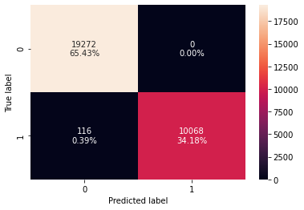

```python
confusion_matrix_sklearn(model, X_train2, y_train2)
```

Checking model performance on test set

```python
decision_tree_perf_test = model_performance_classification_sklearn(
    model, X_test2, y_test2
)
decision_tree_perf_test
```

|  | Accuracy | Recall | Precision | F1 |
| --- | --- | --- | --- | --- |
| 0 | 0.788102 | 0.830669 | 0.845194 | 0.837869 |

The Model appears to be capable of improvement due to the variance in model performance between the training and test data.

# Visualizing the Decision Tree

```python
feature_names = list(X.columns)
print(feature_names)
```

[output not shown]

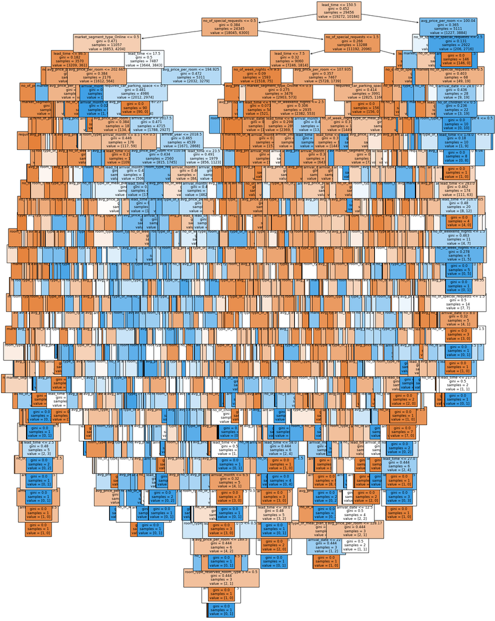

```python
plt.figure(figsize=(20,30))
out = tree.plot_tree(model,feature_names=feature_names,filled=True,fontsize=9,node_ids=False,class_names=None,)
#below code will add arrows to the decision tree split if they are missing
for o in out:
     arrow = o.arrow_patch
     if arrow is not None:
        arrow.set_edgecolor('black')
        arrow.set_linewidth(1)
plt.show()
```

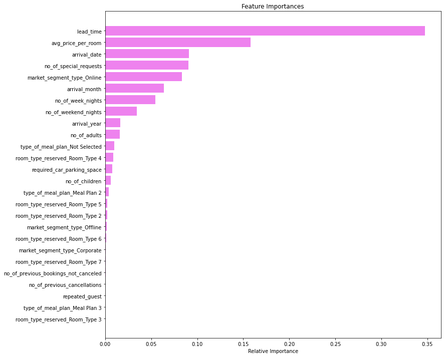

```python
importances = model.feature_importances_
indices = np.argsort(importances)

plt.figure(figsize=(12, 12))
plt.title("Feature Importances")
plt.barh(range(len(indices)), importances[indices], color="violet", align="center")
plt.yticks(range(len(indices)), [feature_names[i] for i in indices])
plt.xlabel("Relative Importance")
plt.show()
```

Lead time and average price per room are the most important features.

```python
# Import more libraries
# To tune different models
from sklearn.model_selection import GridSearchCV
# To perform statistical analysis
import scipy.stats as stats
# To get more metric scores
from sklearn.metrics import (
    make_scorer)
```

# Using GridSearch for Hyperparameter tuning of our tree model

Improving our model performance.

```python
# Choose the type of classifier.
estimator = DecisionTreeClassifier(random_state=1)

# Grid of parameters to choose from

parameters = {
    "max_depth": [np.arange(2, 50, 5), None],
    "criterion": ["entropy", "gini"],
    "splitter": ["best", "random"],
    "min_impurity_decrease": [0.000001, 0.00001, 0.0001],
}

# Type of scoring used to compare parameter combinations
acc_scorer = make_scorer(recall_score)

# Run the grid search
grid_obj = GridSearchCV(estimator, parameters, scoring=acc_scorer, cv=5)
grid_obj = grid_obj.fit(X_train2, y_train2)

# Set the clf to the best combination of parameters
estimator = grid_obj.best_estimator_

# Fit the best algorithm to the data.
estimator.fit(X_train2, y_train2)
```

```
DecisionTreeClassifier(min_impurity_decrease=0.0001, random_state=1)
```

Checking performance on training set

```python
decision_tree_tune_perf_train = model_performance_classification_sklearn(
    estimator, X_train2, y_train2
)
decision_tree_tune_perf_train
```

|  | Accuracy | Recall | Precision | F1 |
| --- | --- | --- | --- | --- |
| 0 | 0.849912 | 0.920039 | 0.860269 | 0.889151 |

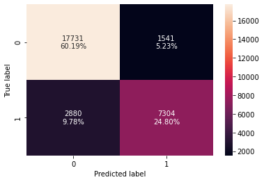

```python
confusion_matrix_sklearn(estimator, X_train2, y_train2)
```

The Metrics have decreased compared to the original training model.

Checking model performance on test set

```python
decision_tree_tune_perf_test = model_performance_classification_sklearn(
    estimator, X_test2, y_test2
)

decision_tree_tune_perf_test
```

|  | Accuracy | Recall | Precision | F1 |
| --- | --- | --- | --- | --- |
| 0 | 0.836581 | 0.903858 | 0.856216 | 0.879392 |

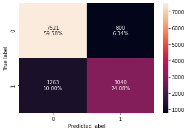

```python
confusion_matrix_sklearn(estimator, X_test2, y_test2)
```

After hyperparameter tuning the model performance improved and the model is simpler.

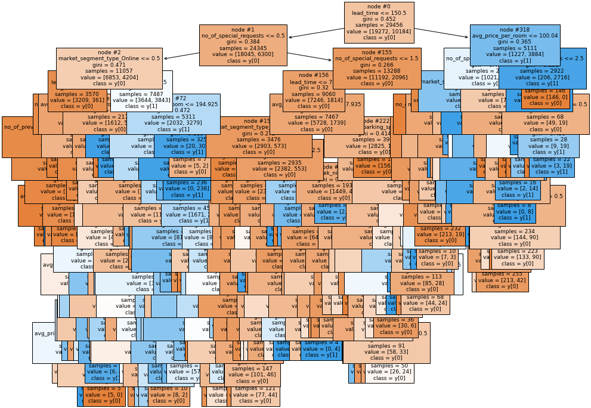

```python
plt.figure(figsize=(15, 12))

tree.plot_tree(
    estimator,
    feature_names=feature_names,
    filled=True,
    fontsize=9,
    node_ids=True,
    class_names=True,
)
plt.show()
```

# Cost Complexity Pruning

```python
clf = DecisionTreeClassifier(random_state=1)
path = clf.cost_complexity_pruning_path(X_train2, y_train2)
ccp_alphas, impurities = path.ccp_alphas, path.impurities
```

```python
pd.DataFrame(path)
```

|  | ccp_alphas | impurities |
| --- | --- | --- |
| 0 | 0.000000 | 0.003938 |
| 1 | 0.000000 | 0.003938 |
| 2 | 0.000000 | 0.003938 |
| 3 | 0.000000 | 0.003938 |
| 4 | 0.000000 | 0.003938 |
| ... | ... | ... |
| 2029 | 0.009015 | 0.305439 |
| 2030 | 0.013320 | 0.318759 |
| 2031 | 0.013448 | 0.332207 |
| 2032 | 0.024083 | 0.380372 |
| 2033 | 0.072033 | 0.452405 |

2034 rows × 2 columns

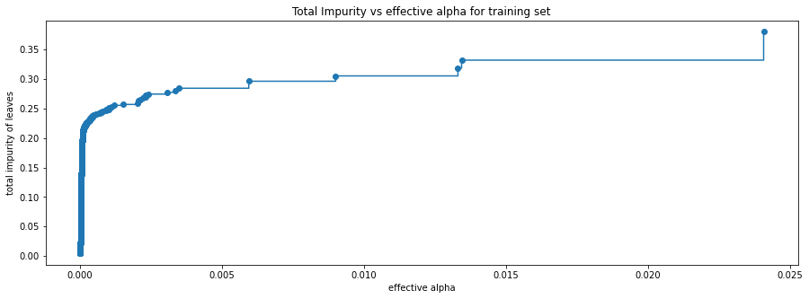

```python
fig, ax = plt.subplots(figsize=(15, 5))
ax.plot(ccp_alphas[:-1], impurities[:-1], marker="o", drawstyle="steps-post")
ax.set_xlabel("effective alpha")
ax.set_ylabel("total impurity of leaves")
ax.set_title("Total Impurity vs effective alpha for training set")
plt.show()
```

Next, we train a decision tree using the effective alphas. The last value in ccp_alphas is the alpha value that prunes the whole tree, leaving the tree, clfs[-1], with one node.

```python
clfs = []
for ccp_alpha in ccp_alphas:
    clf = DecisionTreeClassifier(random_state=1, ccp_alpha=ccp_alpha)
    clf.fit(X_train2, y_train2)
    clfs.append(clf)
print(
    "Number of nodes in the last tree is: {} with ccp_alpha: {}".format(
        clfs[-1].tree_.node_count, ccp_alphas[-1]
    )
)
```

```
Number of nodes in the last tree is: 1 with ccp_alpha: 0.07203320895549131
```

For the remainder, we remove the last element in clfs and ccp_alphas, because it is the trivial tree with only one node. Here we show that the number of nodes and tree depth decreases as alpha increases.

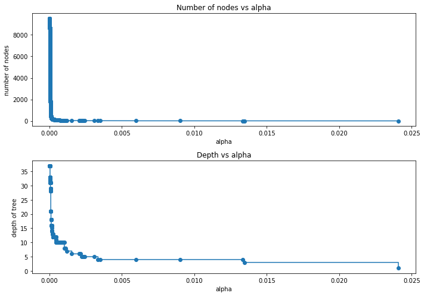

```python
clfs = clfs[:-1]
ccp_alphas = ccp_alphas[:-1]

node_counts = [clf.tree_.node_count for clf in clfs]
depth = [clf.tree_.max_depth for clf in clfs]
fig, ax = plt.subplots(2, 1, figsize=(10, 7))
ax[0].plot(ccp_alphas, node_counts, marker="o", drawstyle="steps-post")
ax[0].set_xlabel("alpha")
ax[0].set_ylabel("number of nodes")
ax[0].set_title("Number of nodes vs alpha")
ax[1].plot(ccp_alphas, depth, marker="o", drawstyle="steps-post")
ax[1].set_xlabel("alpha")
ax[1].set_ylabel("depth of tree")
ax[1].set_title("Depth vs alpha")
fig.tight_layout()
```

## Recall vs alpha for training and testing sets

```python
recall_train = []
for clf in clfs:
    pred_train = clf.predict(X_train2)
    values_train = recall_score(y_train2, pred_train)
    recall_train.append(values_train)
```

```python
recall_test = []
for clf in clfs:
    pred_test = clf.predict(X_test2)
    values_test = recall_score(y_test2, pred_test)
    recall_test.append(values_test)
```

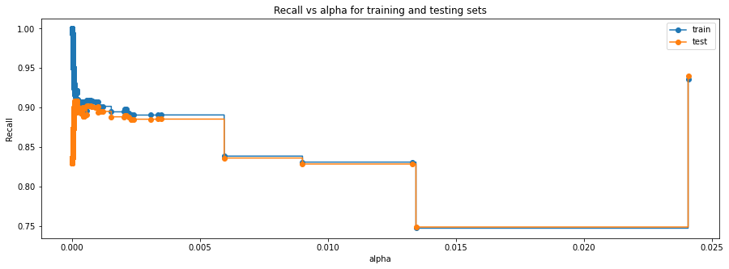

```python
fig, ax = plt.subplots(figsize=(15, 5))
ax.set_xlabel("alpha")
ax.set_ylabel("Recall")
ax.set_title("Recall vs alpha for training and testing sets")
ax.plot(ccp_alphas, recall_train, marker="o", label="train", drawstyle="steps-post")
ax.plot(ccp_alphas, recall_test, marker="o", label="test", drawstyle="steps-post")
ax.legend()
plt.show()
```

```python
# creating the model where we get highest train and test recall
index_best_model = np.argmax(recall_test)
best_model = clfs[index_best_model]
print(best_model)
```

```
DecisionTreeClassifier(ccp_alpha=0.02408262718113155, random_state=1)
```

Checking model performance on training set

```python
decision_tree_postpruned_perf_train = model_performance_classification_sklearn(
    best_model, X_train2, y_train2
)
decision_tree_postpruned_perf_train
```

|  | Accuracy | Recall | Precision | F1 |
| --- | --- | --- | --- | --- |
| 0 | 0.744466 | 0.936333 | 0.74122 | 0.82743 |

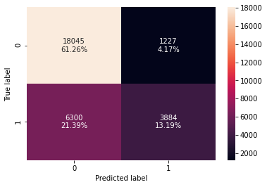

```python
confusion_matrix_sklearn(best_model, X_train2, y_train2)
```

Checking model performance on test set

Checking model performance on test set

```python
decision_tree_postpruned_perf_test = model_performance_classification_sklearn(
    best_model, X_test2, y_test2
)
decision_tree_postpruned_perf_test
```

|  | Accuracy | Recall | Precision | F1 |
| --- | --- | --- | --- | --- |
| 0 | 0.751663 | 0.939551 | 0.748134 | 0.832987 |

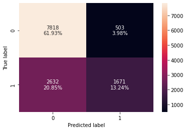

```python
confusion_matrix_sklearn(best_model, X_test2, y_test2)
```

With post-pruning we are getting good and generalized model performance on both training and test set. The recall has improved further.

# Visualizing the Decision Tree

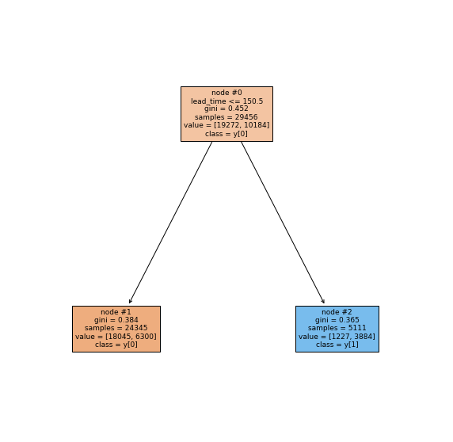

```python
plt.figure(figsize=(10, 10))

out = tree.plot_tree(
    best_model,
    feature_names=feature_names,
    filled=True,
    fontsize=9,
    node_ids=True,
    class_names=True,
)
for o in out:
    arrow = o.arrow_patch
    if arrow is not None:
        arrow.set_edgecolor("black")
        arrow.set_linewidth(1)
plt.show()
```

```python
# Text report showing the rules of a decision tree -

print(tree.export_text(best_model, feature_names=feature_names, show_weights=True))
```

```
|--- lead_time <= 150.50
|   |--- weights: [18045.00, 6300.00] class: 1
|--- lead_time >  150.50
|   |--- weights: [1227.00, 3884.00] class: 2
```

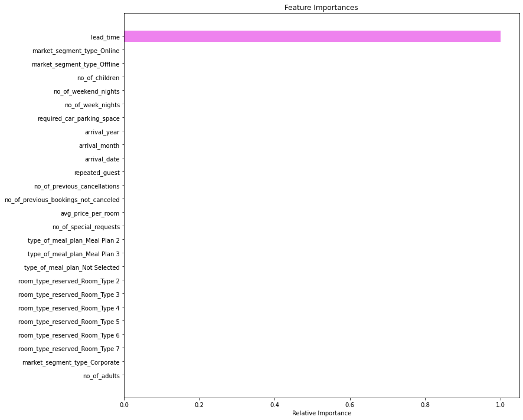

```python
importances = best_model.feature_importances_
indices = np.argsort(importances)

plt.figure(figsize=(12, 12))
plt.title("Feature Importances")
plt.barh(range(len(indices)), importances[indices], color="violet", align="center")
plt.yticks(range(len(indices)), [feature_names[i] for i in indices])
plt.xlabel("Relative Importance")
plt.show()
```

Lead time is the greatest indicator of cancellations.

```python
# training performance comparison

models_train_comp_df = pd.concat(
    [
        decision_tree_perf_train.T,
        decision_tree_tune_perf_train.T,
        decision_tree_postpruned_perf_train.T,
    ],
    axis=1,
)
models_train_comp_df.columns = [
    "Decision Tree sklearn",
    "Decision Tree (Pre-Pruning)",
    "Decision Tree (Post-Pruning)",
]
print("Training performance comparison:")
models_train_comp_df
```

```
Training performance comparison:
```

|  | Decision Tree sklearn | Decision Tree (Pre-Pruning) | Decision Tree (Post-Pruning) |
| --- | --- | --- | --- |
| Accuracy | 0.996062 | 0.849912 | 0.744466 |
| Recall | 1.000000 | 0.920039 | 0.936333 |
| Precision | 0.994017 | 0.860269 | 0.741220 |
| F1 | 0.996999 | 0.889151 | 0.827430 |

- Decision tree with post-pruning is giving the highest recall on the test set.
- The tree with post pruning is not complex and easy to interpret.

# Business Insights

- The lead time of bookings is the greatest influence on cancellations.
- Previous cancellations do not imply causation of future cancellations.
- Online bookings are the most commonly canceled market segment.